# GET00203 - Estatística Computacional 1

Aula 04 - Distribuições amostrais - Parte I

[Rafael Erbisti](https://sites.google.com/site/rerbisti)

## Simulando alguns resultados teóricos

Sabe-se que se $Z \sim N(0,1)$ e $X \sim \chi_\nu^2$ são variáveis aleatórias independentes, então
$$T = \dfrac{Z}{\sqrt{\dfrac{X}{\nu}}} \sim t_{\nu}$$

Iremos simular das distribuições de $Z$ e $X$ e avaliar empiricamente a amostra obtida para $T$ e compará-la com a distribuição teórica $t_{\nu}$.

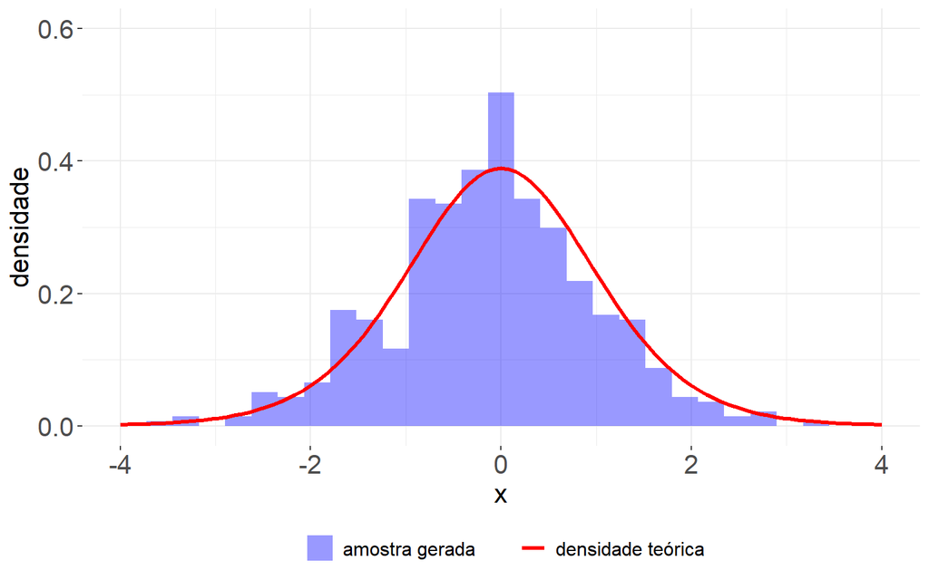

```r
# tamanho da amostra
n = 500

# simulando da distribuição de Z
amostra.z = rnorm(n)

# simulando da distribuição de X com 10 graus de liberdade
nu = 10
amostra.x = rchisq(n, df = nu)

# gerando amostra de T, com 10 graus de liberdade
amostra.t = amostra.z/sqrt(amostra.x/nu)

# avaliando a amostra gerada e a curva teórica da distribuição t com 10 graus de liberdade
ggplot(data = tibble(x = amostra.t), mapping = aes(x = x)) +
  geom_histogram(aes(y = ..density.., fill = "amostra gerada"), alpha = 0.4) +
  stat_function(fun = dt, args = list(df = nu), aes(color = "densidade teórica"),
                linewidth=1.2) +
  labs(y = "densidade", x = "x", fill = "", color = "") +
  xlim(-4, 4) +
  ylim(0, 0.6) +
  scale_fill_manual(values = c("amostra gerada" = "blue")) +
  scale_color_manual(values = c("densidade teórica" = "red")) +
  theme_bw() +
  theme(axis.text.x = element_text(size = 16),
        axis.title.x = element_text(size = 16),
        axis.text.y = element_text(size = 16),
        axis.title.y = element_text(size = 16),
        panel.border = element_blank(),
        legend.position = "bottom",
        legend.text = element_text(size = 12))
```

Outra forma de comparar distribuições empíricas e teóricas é comparar os quantis das distribuições utilizando o gráfico `qq-plot`.

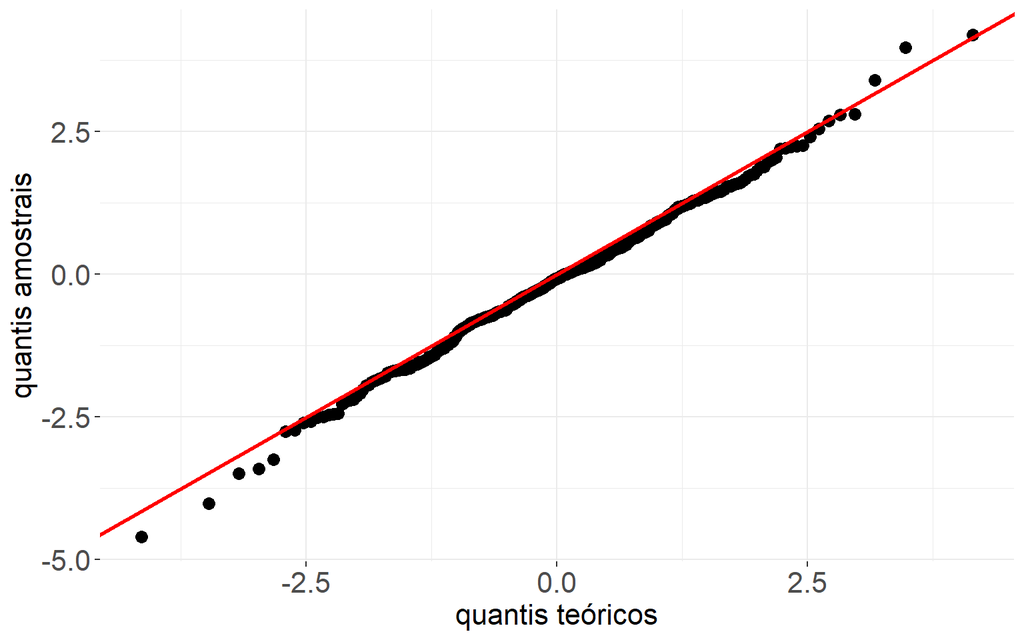

```r
ggplot(data = tibble(x = amostra.t), aes(sample = x)) +
  stat_qq(distribution = qt, dparams = list(df = nu), size = 3) +
  geom_abline(intercept = 0, col = "red", size = 1.2) +
  labs(x = "quantis teóricos",
       y = "quantis amostrais") +
  theme_bw() +
  theme(axis.text.x = element_text(size = 16),
        axis.title.x = element_text(size = 16),
        axis.text.y = element_text(size = 16),
        axis.title.y = element_text(size = 16),
        panel.border = element_blank())
```

> **Atividade:** Simule os seguintes resultados teóricos, comparando os gráficos empíricos e teóricos, além dos quantis das distribuiçõoes.

> **1.** Se $X \sim U(-1,1)$, então $|X| \sim U(0,1)$

> **2.** Se $Y \sim U(0,1)$, então $-\log Y \sim Exp(1)$

> **3.** Se $Z \sim N(0,1)$, então $Z^2 \sim \chi_1^2$

#### Teorema do Limite Central

Para uma A.A.S. $(X_1,X_2,\ldots,X_n)$ retiradas de uma população com média $\mu$ e variância $\sigma^2$ finita, a distribuição amostral da média $\bar{X}$ aproxima-se, para $n$ grande, de uma distribuição normal, com média $\mu$ e variância $\sigma^2/n$.

Portanto, veremos empiricamente o resultado do Teorema do Limite Central:

##### Exemplo 1: Seja $X \sim Poisson(\lambda)$ e $X_1, X_2, \ldots, X_n$ uma amostra iid dessa população. Então, a distribuição da média amostral $\bar{X}$ tenderá para uma normal com média $\mu = \lambda$ e variância igual a $\lambda/n$.

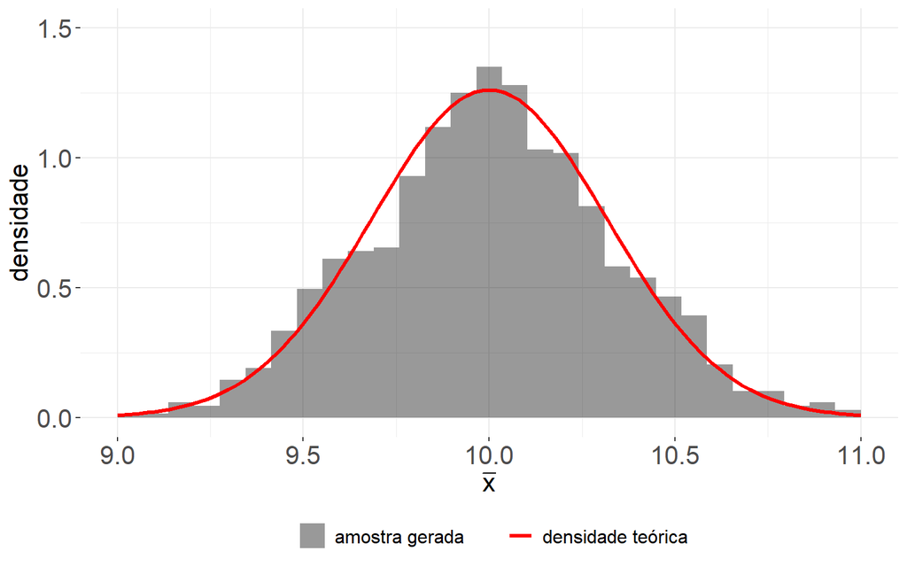

```r
# tamanho da amostra (x1, ..., xn)
n = 100

# parâmetro da distribuição desejada
lambda = 10

# calculando a média e a variância populacional
med.pop = lambda
var.pop = lambda

# definindo o número de amostras da distribuição de x_barra: (x_barra_1, ..., x_barra_m)
m = 1000

# definindo a matriz que armazenará os valores amostrados
x = matrix(data = NA, ncol = m, nrow = n)

# inicializando o vetor que armazenará as médias amostrais
xbarra = NULL

# obtendo a amostra e calculando a sua respectiva média
for(j in 1:m){
  # btendo a amostra x1, x2, ..., xn
  x[,j] = rpois(n, lambda)
  # calculando a media da amostra
  xbarra[j] = mean(x[,j])
}

# avaliando o histograma das médias amostrais
ggplot(data = tibble(valores = xbarra), mapping = aes(x = valores)) +
  geom_histogram(aes(y = ..density.., fill = "amostra gerada"), alpha = 0.4) +
  stat_function(fun = dnorm, args = list(mean = med.pop,
                                         sd = sqrt(var.pop/n)),
                aes(color = "densidade teórica"),
                linewidth=1.2) +
  xlim(9, 11) +
  ylim(0, 1.5) +
  scale_fill_manual(values = c("amostra gerada" = "black")) +
  scale_color_manual(values = c("densidade teórica" = "red")) +
  labs(x = expression(bar(x)),
       y = "densidade", fill = "", colour = "") +
  theme_bw() +
  theme(axis.text.x = element_text(size = 16),
        axis.title.x = element_text(size = 16),
        axis.text.y = element_text(size = 16),
        axis.title.y = element_text(size = 16),
        panel.border = element_blank(),
        legend.position = "bottom",
        legend.text = element_text(size = 12))
```

##### Exemplo 2: Seja $X \sim N(\mu,\sigma^2)$ e $X_1, X_2, \ldots, X_n$ uma amostra iid dessa população. Então, a distribuição da média amostral $\bar{X}$ tenderá para uma normal com média $\mu$ e variância igual a $\sigma^2/n$.

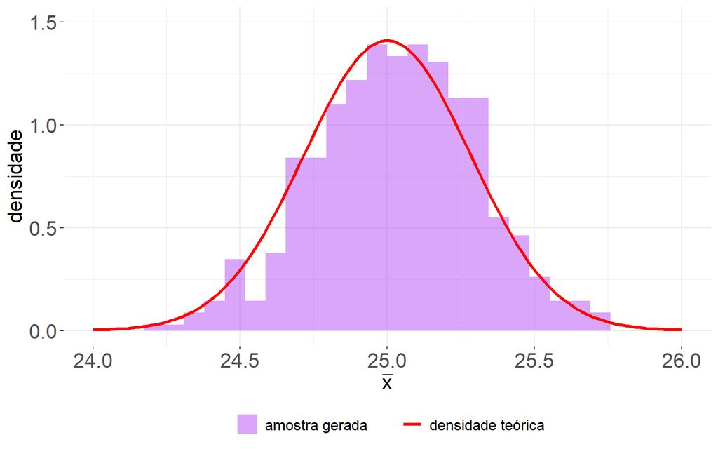

```r
# tamanho da amostra (x1, ..., xn)
n = 200

# parâmetro da distribuição desejada
mu = 25
sigma2 = 16

# calculando a média e a variância populacional
med.pop = mu
var.pop = sigma2

# definindo o número de amostras da distribuição de x_barra: (x_barra_1, ..., x_barra_m)
m = 500

# definindo a matriz que armazenará os valores amostrados
x = matrix(data = NA, ncol = m, nrow = n)

# inicializando o vetor que armazenará as médias amostrais
xbarra = NULL

# obtendo a amostra e calculando a sua respectiva média
for(j in 1:m){
  # btendo a amostra x1, x2, ..., xn
  x[,j] = rnorm(n, mean = mu, sd = sqrt(sigma2))
  # calculando a media da amostra
  xbarra[j] = mean(x[,j])
}

# avaliando o histograma das médias amostrais
ggplot(data = tibble(valores = xbarra), mapping = aes(x = valores)) +
  geom_histogram(aes(y = ..density.., fill = "amostra gerada"), alpha = 0.4) +
  stat_function(fun = dnorm, args = list(mean = med.pop,
                                         sd = sqrt(var.pop/n)),
                aes(color = "densidade teórica"),
                linewidth=1.2) +
  xlim(24, 26) +
  ylim(0, 1.5) +
  scale_fill_manual(values = c("amostra gerada" = "purple")) +
  scale_color_manual(values = c("densidade teórica" = "red")) +
  labs(x = expression(bar(x)),
       y = "densidade", fill = "", colour = "") +
  theme_bw() +
  theme(axis.text.x = element_text(size = 16),
        axis.title.x = element_text(size = 16),
        axis.text.y = element_text(size = 16),
        axis.title.y = element_text(size = 16),
        panel.border = element_blank(),
        legend.position = "bottom",
        legend.text = element_text(size = 12))
```

> **Desafio:** Considere a população $\{1,3,5,5,7\}$ e faça o que se pede:

> **a)** Retire 1000 amostras de tamanho $n=2$ desta população

> **b)** Armazene as amostras de modo que em cada coluna fique uma amostra de tamanho $n$

> **c)** Obtenha as médias de cada amostra

> **d)** Faça uma representação gráfica para ajudar a visualizar o resultado do TLC (siga o que foi visto em aula).

> **e)** Repita o que foi feito variando o valor de $n$ (use $n$ = 5, 20, 50, 200 e 400). O que acontece?